# Matplotlib

Matplotlib is a plotting library for the Python programming language and used for Visualization. It is 2D plotting library which produces publication quality figures in a variety of hardcopy formats and interactive environments across platforms. It can be used in Python scripts, the Python and IPython shells, the Jupyter notebook, web application servers. It is very customizable and extremely configurable. It is used in the data visualization.Pandas actually makes the implementation simpler because it hooks up directly to matplotlib from the back end.

## Data Visualization

Data Visualization is the presentation of data in a pictorial or graphical format. In order to communicate information like pattern, trend and scope of the data clearly and efficiently we use data visualization. It is achieved using graphs, plots, information graphics etc.

Data visualization can help us to find the insight in Data. It can also help to analyze the effect of one parameter due to change in other parameter and vice-versa.

## Why do we need Data Visualization?

As a Data Scientist you will have good knowledge about the given data, once you do all the analysis of it. But it is not possible for people with less or no knowledge about the analysis techniques to understand about that data in the same way as you do. So inorder to make them understand the analysis you make out from the given data you present the analysis or data in the form of graphs and plots. Because we know the "a picture is equivalent to 1000 words".

Matplotlib ships with several add-on toolkits, including 3d plotting with mplot3d, axes helpers in axes_grid1 and axis helpers in axisartist. Matplotlib has pledged to not support Python 2 past 2020 by signing the Python 3 Statement.

# Contents

1. Installation of Matplotlib
2. Scatter Plots
3. Legends, Title, Labels
4. Line Plots
5. Adding style to graph
6. Bar Plots
7. Histogram Plots
8. Stack or Area Plots
9. Pie Charts
10. Multiple Plots

### Installation of Matplotlib

In Anaconda

conda install -c conda-forge matplotlib

In Debian/Ubuntu

sudo apt-get install python3-matplotlib

# Scatter Plot

We use Scatter Plot in order to see the relationship between two variables i.e either to compare two variables or to see the correlation between those two variables. Observation How one variable is changing with respect to the other variable. How close two data points are - closness represents the similarity among them.

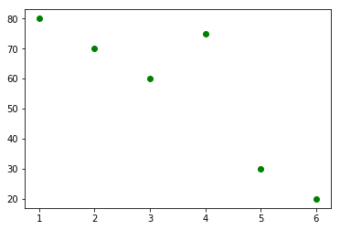

```python
import matplotlib.pyplot as plt

sm = [1,2,3,4,5,6]
m = [80,70,60,75,30,20]

plt.scatter(sm,m,label ='social-media',color='g')
plt.show()
```

# Legends, Title, Labels

Legend The dictionay meaning of legend is "Concise explanation of the symbols used in a chart, diagram, drawing, map, table, etc. A legend is usually conspicuously displayed in a tabular form." The legend is linked to the data being graphically displayed in the plot area of the chart. Title It shows the title of the chart i.e. what the chart is for. Labels Here labels represent the axis i.e x-axis and y-axis. On x-axis we will have independent variable and on y-axis we will have dependent variables.

## Line Plots

A line plot is a graph that shows the frequency of data occurring along a number line. Line plots provide a quick and easy way to organize data and are best used when comparing fewer than 25 different numbers.

[figure not shown]

```python
import matplotlib.pyplot as plt

sm = [1,2,3,4,5,6]
m = [80,70,60,75,30,20]

plt.title("Scocial-media effect on marks")
plt.xlabel("Time spent on Social Media(sm)")
plt.ylabel("Marks obtained(m)")
plt.scatter(sm,m,color='k')
plt.plot(sm,m,label="social-media",color='g')

plt.legend()
plt.show()
```

# Adding style to graph

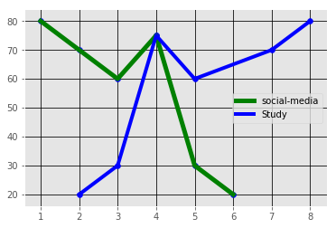

```python
import matplotlib.pyplot as plt
from matplotlib import style

style.use('ggplot')

sm = [1,2,3,4,5,6]
m = [80,70,60,75,30,20]
s = [8,7,5,4,3,2]

plt.plot(sm,m,'g',label='social-media',linewidth=5)
plt.plot(s,m,'b',label='Study',linewidth=4)
plt.scatter(sm,m,color='b')
plt.scatter(s,m,color='b')
plt.legend()

plt.grid(True,color='k')
plt.show()

#add the following in the chart
#title - study and social media impact on marks
#y-axis - marks obtained
#x-axis - time spend in hours
```

# Bar Graph

A bar graph is a chart that uses bars to show comparisons between categories of data. The bars can be either horizontal or vertical. Bar graphs with vertical bars are sometimes called vertical bar graphs. A bar graph will have two axes. One axis will describe the types of categories being compared, and the other will have numerical values that represent the values of the data. Bar graph correspond to categorical variable. GDP growth for every cities.

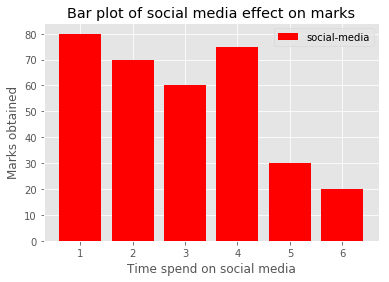

```python
import matplotlib.pyplot as plt
from matplotlib import style

style.use('ggplot')

sm = [1,2,3,4,5,6]
m = [80,70,60,75,30,20]
s = [8,7,5,4,3,2]

plt.bar(sm,m,label='social-media',color='r')

plt.title("Bar plot of social media effect on marks")
plt.xlabel('Time spend on social media')
plt.ylabel('Marks obtained')

plt.legend()

plt.show()
```

# Histogram

A histogram is an accurate representation of the distribution of numerical data. It is an estimate of the probability distribution of a continuous variable and was first introduced by Karl Pearson. It differs from a bar graph, in the sense that a bar graph relates two variables, but a histogram relates only one. Histogram talks about the distribution of a feature in our dataset and they will answer two questions. 1. Where? where in the domain of your feature or rather where in the possible value that your feature can take on all our sample located. 2. How many sample are located exactly? Histogram Corresponds to the use of quantitive variable. Age group contribution to GDP

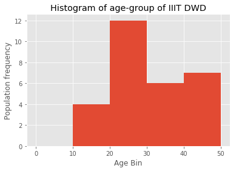

```python
import matplotlib.pyplot as plt

college_pop_age = [19,19,18,20,19,20,21,21,22,24,24,25,26,27,35,28,29,36,38,39,36,39,40,42,44,47,48,49,50]

bins = [0,10,20,30,40,50]

plt.hist(college_pop_age,bins,histtype='bar')

plt.title("Histogram of age-group of IIIT DWD")
plt.xlabel('Age Bin')
plt.ylabel('Population frequency')
plt.show()

#parameter that can be added
#width = 0.8 show the spacing between bar by default it will be zero
```

#### Histogram VS Bar graph

1. A histogram represents the frequency distribution of continuous variables. Conversely, a bar graph is a diagrammatic comparison of discrete variables.
2. Histogram presents numerical data whereas bar graph shows categorical data. The histogram is drawn in such a way that there is no gap between the bars.

# Stack or Area Plots

This chart becomes hard to read if too many groups are displayed and if the patterns are really different between groups.

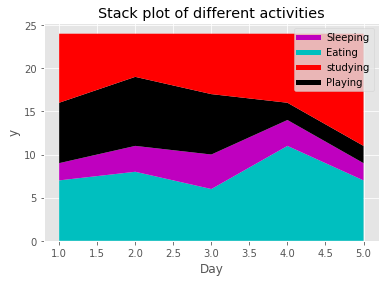

```python
import matplotlib.pyplot as plt

days = [1,2,3,4,5]

sleeping = [7,8,6,11,7]
eating =   [2,3,4,3,2]
studying = [7,8,7,2,2]
playing =  [8,5,7,8,13]

plt.stackplot(days, sleeping,eating,studying,playing, colors=['c','m','k','r'])

plt.xlabel('Day')
plt.ylabel('y')
plt.title('Stack plot of different activities')

plt.plot([],[],color='m', label='Sleeping', linewidth=5)
plt.plot([],[],color='c', label='Eating', linewidth=5)
plt.plot([],[],color='r', label='studying', linewidth=5)
plt.plot([],[],color='k', label='Playing', linewidth=5)

plt.legend()

plt.show()
```

# Pie Charts

A pie chart is a circular statistical graphic, which is divided into slices to illustrate numerical proportion. In a pie chart, the arc length of each slice, is proportional to the quantity it represents. It can sometimes become very difficult to compare the change in the features if we have two pie charts. And Pie charts can be replaced in most cases by other plots such as the bar chart, box plot or dot plots.

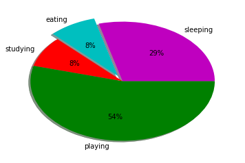

```python
import matplotlib.pyplot as plt


sleeping = [7,8,6,11,7]
eating =   [2,3,4,3,2]
studying = [7,8,7,2,2]
playing =  [8,5,7,8,13]

slices = [7,2,2,13]
activities = ['sleeping','eating','studying','playing']
cols = ['m','c','r','g']
plt.pie(slices,labels = activities , colors = cols, shadow=True,explode=(0,0.1,0,0),autopct = '%1.f%%')

plt.show()
```

# Multiple Plots

It will be utilized in the situation where we need to draw two graph in same figure show that some feature change can be easly be observed.

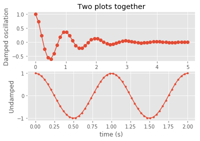

```python
import numpy as np
import matplotlib.pyplot as plt


x1 = np.linspace(0.0, 5.0)
x2 = np.linspace(0.0, 2.0)

y1 = np.cos(2 * np.pi * x1) * np.exp(-x1)
y2 = np.cos(2 * np.pi * x2)

plt.subplot(2, 1, 1)
plt.plot(x1, y1, 'o-')
plt.title('Two plots together')
plt.ylabel('Damped oscillation')

plt.subplot(2, 1, 2)
plt.plot(x2, y2, '.-')
plt.xlabel('time (s)')
plt.ylabel('Undamped')

plt.show()
```

# Thank you

**Sanjeet kumar**  
School of AI, Hubli  
sanjeetiiitd@gmail.com